# Figures and tables Consensus Path DB

Stephanie Hickey

6/22/2022

## Set up

```r
knitr::opts_chunk$set(echo = TRUE)
library(tidyverse)
library(patchwork)
library(parallel)
library(ggprism)
source("./src/chronic_inflammation_functions.R")
figure_path = "./results/prediction_clusters_same_graph"
```

## Figure 1: expansion and clustering

### Figure 1a:Prediction and clustering schematic

Made in Google Slides

### For labeling trait types for the rest of Figure 1

I added the TraitType column to diseases_used_in_study.csv by hand to show whether the disease was categorized as a complex or autoimmune disease in the second column.

```r
# get complex vs ai labels
c_v_ai = read.csv("./data/diseases_used_in_study.csv", row.names = 1)

ai =
  c_v_ai %>%
  filter(TraitType == "Autoimmune Disease") %>%
  pull(Disease)

complex =
  c_v_ai %>%
  filter(TraitType == "Complex Disease") %>%
  pull(Disease)
```

### load data for figure1 – gene cluster assignments

Load the gene cluster assignment files for the real traits. These files are the output of filterAndClusterGeneplexusPredictions.R.

```r
files = list.files("./results/prediction_clusters_same_graph/clusters/predicted_withConsensusPathDB--clustered_on_ConsensusPathDB",
full.names = T)

remove_files = c("Fake", "inflamm", "Height_gene_shot", "Colitis")

files = files[grep(paste(remove_files,collapse="|"), files, invert = T)]

clust_list = mclapply(files,
                   read.csv,
                   row.names = 1,
                   mc.cores = detectCores()-1)

clust_df = do.call(rbind, clust_list)

# add trait type to the cluster df
clust_df =
  clust_df %>%
  mutate(TraitType =
           case_when(Disease %in% ai ~ "Autoimmune Disease",
                     Disease %in% complex ~ "Complex Disease",
                     !Disease %in% c(ai, complex)  ~ "Non-disease Trait"))
```

### Filter for Diseases with:

- n seed genes >= 15
- average GenePlexus three-fold CV log_{2}(auPRC/prior) >= 1

```r
load("./results/GenePlexus_parameter_checks/Geneplexus_summary_new_networks.Rdata")
cv_df =
  summary_df %>%
  filter(Network == "ConsensusPathDB") %>%
  select(Disease,
         nSeeds,
         CVscore) # is average GenePlexus three-fold CV log2(auPRC/prior)

keep_disease =
  cv_df %>%
  filter(nSeeds >= 15,
         CVscore >= 1,
         !grepl("inflamm", Disease),
         Disease != "Colitis") %>%
  pull(Disease) %>%
  unique()

clust_df =
  clust_df %>%
  filter(Disease %in% keep_disease)
```

### Filter out diseases with no clustered fake traits

Grep the number of clustered fake traits for each disease from the output files of submit_clusterRandomGenes.R

```bash
cd ./run/sbatches_clusterRandomGenes
grep -hnr --with-filename "number clustered" *ConsensusPathDB.out > ConsensusPathDB_number_clustered.txt
```

```r
nclust = read.delim("./run/sbatches_clusterRandomGenes/ConsensusPathDB_number_clustered.txt", header =F, sep = " ")
nclust$nFakesClustered = gsub("number clustered = ", "", nclust$V2)
nclust$nFakesClustered = as.numeric(nclust$nFakesClustered)
nclust$Disease = gsub(paste0("_ConsensusPathDB",".*"), "", nclust$V1)

nclust =
  nclust %>%
  select(nFakesClustered,
         Disease)

enough_fakes =
  nclust %>%
  filter(nFakesClustered > 0) %>%
  pull(Disease)

clust_df =
  clust_df %>%
  filter(Disease %in% enough_fakes)
```

### Figure 1b: Number of disease genes (seeds + predicted)

```r
# plot median n genes per trait type

clust_df$TraitType = factor(clust_df$TraitType,
                       levels = c("Autoimmune Disease",
                                  "Complex Disease",
                                  "Non-disease Trait"))

nGenes =
  clust_df %>%
  group_by(TraitType,
           Disease) %>%
  tally(name = "nGenes")

Fig1b =
 nGenes %>%
  ggplot(aes(x = TraitType,
             y = nGenes)) +
  geom_jitter(shape=16,
              colour = "#90A4AE",
              position=position_jitter(0.2)) +
  geom_boxplot(color = c("#bc3754"),
               fill = "NA",
               outlier.size=0,
               outlier.shape=NA) +
  theme_classic() +
  #theme(axis.text.x = element_text(angle = 45,
                                  # hjust=1)) +
  #xlab("Trait Type") +
  theme(axis.title.x=element_blank(),
        axis.text.x=element_blank()) +
  ylab("Number of genes") +
  ggtitle('(B)')
```

### Figure 1c: Fraction predicted genes

```r
#find n predicted genes

nPredicted =
  clust_df %>%
  filter(GeneType == "predicted") %>%
  group_by(TraitType,
           Disease) %>%
  tally(name = "nPredictedGenes")

nGenes = left_join(nGenes, nPredicted)
nGenes$propPredicted = nGenes$nPredictedGenes/nGenes$nGenes

Fig1c =
  nGenes %>%
  ggplot(aes(x = TraitType,
             y = propPredicted)) +
  geom_jitter(shape=16,
              colour = "#90A4AE",
              position=position_jitter(0.2)) +
  geom_boxplot(color = c("#bc3754"),
               fill = "NA",
               outlier.size=0,
               outlier.shape=NA) +
  theme_classic() +
  theme(axis.text.x = element_text(angle = 45,
                                   hjust=1)) +
  theme(axis.title.x=element_blank()) +
  ylab("Proportion predicted genes") +
  ggtitle('(C)')
```

### Figure 1d: Number of clusters containing >=5 genes

```r
nGenesPerCluster =
  clust_df %>%
  group_by(Disease,
           Cluster,
           TraitType) %>%
  tally()

nClusters5 =
  nGenesPerCluster %>%
  filter(n >= 5) %>%
  group_by(Disease,
           TraitType) %>%
  tally(name="nClusters5")

Fig1d =
  nClusters5 %>%
  ggplot(aes(x = TraitType,
             y = nClusters5)) +
  geom_jitter(shape=16,
              colour = "#90A4AE",
              position=position_jitter(0.2)) +
  geom_boxplot(color = c("#bc3754"),
               fill = "NA",
               outlier.size=0,
               outlier.shape=NA) +
  theme_classic() +
  theme(axis.text.x = element_text(angle = 45,
                                   hjust=1)) +
  theme(axis.title.x=element_blank()) +
  ylab("Clusters size >= 5") +
  ggtitle('(D)')
```

### Figure 1e: Fraction of genes in clusters containing >=5 genes

```r
clusters5 =
  nGenesPerCluster %>%
  filter(n >= 5) %>%
  pull(Cluster)

nGenes5 =
  clust_df %>%
  select(Disease,
         Cluster,
         TraitType) %>%
  filter(Cluster %in% clusters5) %>%
  group_by(Disease,
           TraitType) %>%
  tally(name="nGenesInClusterSize5")

nGenes  = left_join(nGenes, nGenes5)
nGenes$nGenesInClusterSize5[is.na(nGenes$nGenesInClusterSize5)] = 0
nGenes$propClustered = nGenes$nGenesInClusterSize5/nGenes$nGenes

Fig1e =
  nGenes %>%
  ggplot(aes(x = TraitType,
             y = propClustered)) +
  geom_jitter(shape=16,
              colour = "#90A4AE",
              position=position_jitter(0.2)) +
  geom_boxplot(color = c("#bc3754"),
               fill = "NA",
               outlier.size=0,
               outlier.shape=NA) +
  theme_classic() +
  theme(axis.text.x = element_text(angle = 45,
                                   hjust=1)) +
  theme(axis.title.x=element_blank()) +
  ylab("Proportion clustered genes") +
  ggtitle('(E)')
```

### Figure 1f: Fraction of GOBP enriched clusters

These files are the output of find_GOBP_enriched_clusters_GenePlexus.R

```r
# prep gobp enrichment df
go_path = "./results/prediction_clusters_same_graph/GOBP_enrichment"

go_files = list.files(go_path,
                      full.names = T,
                      pattern = "ConsensusPathDB")

go_list = mclapply(go_files,
                   read.csv,
                   row.names = 1,
                   mc.cores= detectCores()-1)
godf = do.call(rbind, go_list)

# add label to gobp file
godf =
  godf %>%
  filter(Disease %in% keep_disease) %>%
  mutate(TraitType =
           case_when(Disease %in% ai ~ "Autoimmune Disease",
                     Disease %in% complex ~ "Complex Disease",
                     !Disease %in% c(ai, complex)  ~ "Non-disease Trait"))

# how many clusters have at least one sig overlap?
n_sig =
  godf %>%
  filter(FDR < .05) %>%
  group_by(Cluster,
           Disease,
           TraitType) %>%
  tally() %>%
  arrange(n)

# per disease
n_sig_per_disease =
  n_sig %>%
  group_by(Disease,
           TraitType) %>%
  tally(name="nGOBP_enriched")

nClusters5 = left_join(nClusters5, n_sig_per_disease)
nClusters5$nGOBP_enriched[is.na(nClusters5$nGOBP_enriched)] = 0
nClusters5$propGOBP_enriched = nClusters5$nGOBP_enriched/nClusters5$nClusters5

Fig1f =
  nClusters5 %>%
  ggplot(aes(x = TraitType,
             y = propGOBP_enriched)) +
  geom_jitter(shape=16,
              colour = "#90A4AE",
              position=position_jitter(0.2)) +
  geom_boxplot(color = c("#bc3754"),
               fill = "NA",
               outlier.size=0,
               outlier.shape=NA) +
  theme_classic() +
  theme(axis.text.x = element_text(angle = 45,
                                   hjust=1)) +
  theme(axis.title.x=element_blank()) +
  ylab("Proportion GOBP enriched") +
  ggtitle('(F)')
```

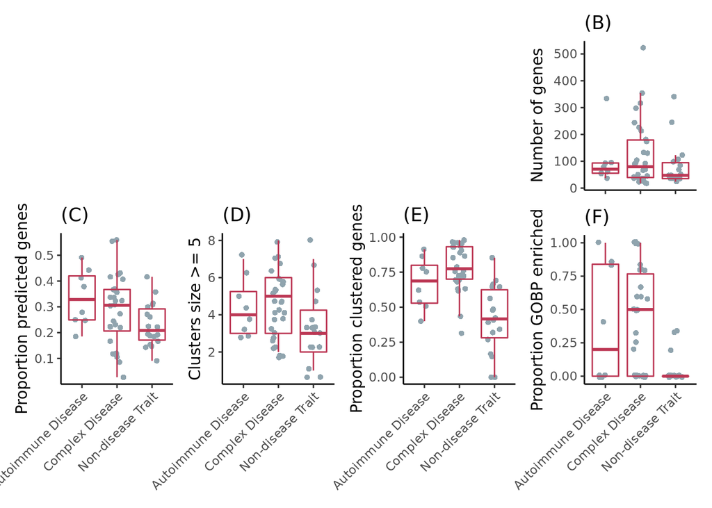

```r
fig1 =
  (plot_spacer() / Fig1c) |
  (plot_spacer() / Fig1d) |
  (plot_spacer() / Fig1e) |
  (Fig1b / Fig1f)

ggsave(fig1, file = paste0(figure_path, "/Figure1.png"),
       width = 180, height = 127, dpi = 300, units = "mm")
fig1
```

## Figure 2: Chronic infammation cluster overlaps

### Figure 2a: Number of traits overlapping at least one chronic inflammation cluster

These data are the output of calculatePermutedFDR_faketraits.R

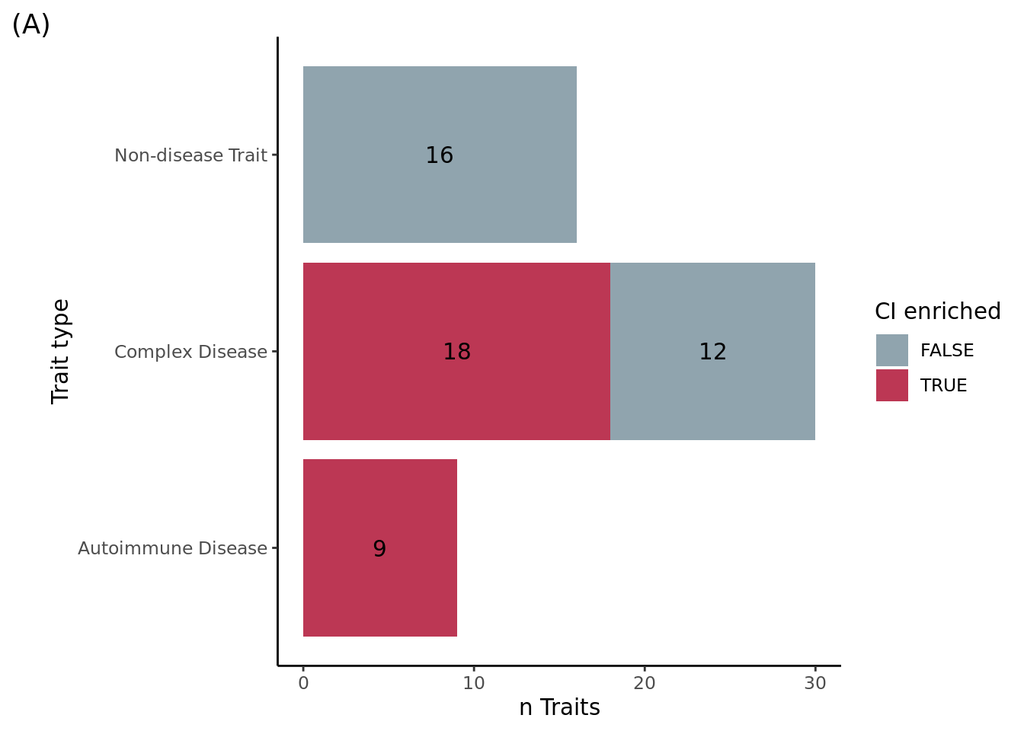

```r
# load the overlap results file = res_df
res_df = loadRData("./results/prediction_clusters_same_graph/scores/chronic_inflammation_gene_shot_pubs_greater10_thresh=0.8_predicted_with_ConsensusPathDB_clusteredOn_ConsensusPathDB_overlap_results.Rdata")

# add TraitType to res_df
res_df =
  res_df %>%
  mutate(TraitType =
           case_when(Disease %in% ai ~ "Autoimmune Disease",
                     Disease %in% complex ~ "Complex Disease",
                     !Disease %in% c(ai, complex)  ~ "Non-disease Trait"))
res_df =
  res_df %>%
  filter(Disease %in% keep_disease)


# filter for significant overlaps
cutoff = 0.05
sig = res_df %>%
  filter(PermutedFDR < cutoff,
         Enrichment > 0)

# diseases with at least one cluster
# significantly overlapping a CI cluster
sig_disease =
  sig %>%
  ungroup() %>%
  select(Disease,
         TraitType) %>%
  distinct() %>%
  mutate(Signficant_Overlap = TRUE)

#make not-significant df
#filter for keep_disease
not_sig_diseases =
  res_df %>%
  ungroup() %>%
  filter(!Disease %in% sig_disease$Disease) %>%
  select(Disease,
         TraitType) %>%
  distinct() %>%
  mutate(Signficant_Overlap = FALSE)

# bind
sig_disease = rbind(sig_disease,
                    not_sig_diseases)

# tally sig and not sig by trait type
tally_sig_disease =
  sig_disease %>%
  group_by(TraitType,
           Signficant_Overlap) %>%
  tally()

# plot
tally_sig_disease$TraitType = factor(tally_sig_disease$TraitType,
                                   levels = c("Autoimmune Disease",
                                              "Complex Disease",
                                              "Non-disease Trait"))

Fig2a =
  ggplot(tally_sig_disease,
       aes(x = TraitType,
           y = n,
           fill = Signficant_Overlap)) +
  geom_bar(stat="identity") +
  geom_text(aes(label = n),
            position = position_stack(vjust = 0.5)) +
  theme_classic() +
  scale_fill_manual(values=c("#90a4ae",
                             "#bc3754")) +
  xlab("Trait type") +
  ylab("n Traits") +
  guides(fill = guide_legend("CI enriched")) +
  labs(tag = '(A)') +
  coord_flip()

Fig2a
```

### Figure 2b: Proportion of CI overlapping clusters per disease

```r
res_df =
  res_df %>%
  mutate(SignificantOverlap =
           case_when(PermutedFDR > .05 | Enrichment < 0 ~ FALSE,
                     PermutedFDR <= .05 & Enrichment > 0 ~ TRUE))

sig_clust_tally =
  res_df %>%
  filter(SignificantOverlap == "TRUE") %>%
  group_by(Disease, TraitType) %>%
  tally(name="nSigCluster")

clust_total =
  res_df %>%
  group_by(Disease, TraitType) %>%
  tally(name="nCluster")

sig_clust_tally =
  left_join(clust_total, sig_clust_tally) %>%
  filter(!is.na(nSigCluster)) %>%
  mutate(propSig = nSigCluster/nCluster)

sig_clust_tally$TraitType = gsub(" Disease", "", sig_clust_tally$TraitType)

Fig2b =
sig_clust_tally %>%
 ggplot(aes(x = TraitType,
            y = propSig)) +
  geom_jitter(shape=16,
              colour = "#90A4AE",
              position=position_jitter(0.2)) +
  geom_boxplot(color = c("#bc3754"),
               fill = "NA",
               outlier.size=0,
               outlier.shape=NA) +
  ylab("Proportion CI enriched") +
  labs(tag = "(B)") +
  theme_classic() +
  #theme(axis.text.x = element_text(angle = 45, hjust=1)) +
  theme(axis.title.x=element_blank()) +
  theme(plot.title=element_text(hjust=-0.13))

  ggsave(Fig2b,
       file = paste0(figure_path,
                     "/Fig2b_check.png"),
       width = 4,
       height = 4,
       dpi = 300)
```

### Figure 2c: Chronic inflammation score of non-seed genes in overlapping and non-overlapping clusters

```r
res_clust =
  res_df %>%
  ungroup() %>%
  rename(ChronicInflammationSource = Group1,
         Cluster = Group2) %>%
  left_join(clust_df) %>%
  select(Gene,
         Disease,
         Cluster,
         TraitType,
         PredictionNetwork,
         ClusterGraph,
         ChronicInflammationSource,
         ChronicInfThreshold,
         Enrichment,
         PermutedFDR,
         SignificantOverlap) %>%
  filter(!is.na(PermutedFDR)) # clusters with fewer than 5 genes

# load gene shot pubs 10 gene plexus predictions
cidf = read.delim("/mnt/research/compbio/krishnanlab/projects/chronic_inflammation/results/GenePlexus_output/chronic_inflammation_gene_shot_pubs_greater10--ConsensusPathDB--Adjacency--GO--predictions.tsv")

cidf =
  cidf %>%
  select(Entrez,
         Probability,
         Class.Label) %>%
  rename(Gene = Entrez)

clust_pred =
  left_join(res_clust, cidf) %>%
  mutate(CI_GeneType =
           case_when(Probability < 0.8 ~ "not used for overlap",
                     Probability >= 0.8 ~ "used for overlap"))

clust_pred_mean =
  clust_pred %>%
  group_by(Cluster,
           CI_GeneType) %>%
  mutate(MeanProb = mean(Probability)) %>%
  select(Cluster,
         TraitType,
         ClusterGraph,
         PredictionNetwork,
         ChronicInflammationSource,
         ChronicInfThreshold,
         CI_GeneType,
         MeanProb,
         SignificantOverlap) %>%
  distinct()

# wilcox test

wtest_false =
  clust_pred_mean %>%
  ungroup %>%
  filter(CI_GeneType == "not used for overlap",
         TraitType != "Non-disease Trait",
         SignificantOverlap == "FALSE") %>%
  pull(MeanProb)

wtest_true =
  clust_pred_mean %>%
  ungroup %>%
  filter(CI_GeneType == "not used for overlap",
         TraitType != "Non-disease Trait",
         SignificantOverlap == "TRUE") %>%
  pull(MeanProb)

wtest = wilcox.test(wtest_true, wtest_false,
                    alternative = "greater")$p.value
```

```r
# plot
df_p_val = data.frame(group1 = "FALSE",
                      group2 = "TRUE",
                      label = paste0("p = ", signif(wtest, 2)),
                      y.position = .40)

clust_pred_mean$SignificantOverlap =
  factor(clust_pred_mean$SignificantOverlap,
         levels = c("FALSE","TRUE"))

Fig2c =
  clust_pred_mean %>%
  filter(CI_GeneType == "not used for overlap",
         TraitType != "Non-disease Trait", # plot only real diseases
         ) %>%
  ggplot(aes(x = SignificantOverlap,
             y = MeanProb)) +
  geom_jitter(shape=16,
              colour = "#90A4AE",
              position=position_jitter(0.2)) +
  geom_boxplot(color = c("#bc3754"),
               fill = "NA",
               outlier.size=0,
               outlier.shape=NA) +
  ylab("mean CI probability per cluster") +
  xlab("CI enriched") +
  labs(tag = "(C)") +
  add_pvalue(df_p_val,
             xmin = "group1",
             xmax = "group2",
             label = "label",
             y.position = "y.position") +
  theme_classic() +
  theme(plot.title=element_text(hjust=-0.13))

ggsave(Fig2c,
       file = paste0(figure_path,
                     "/Fig2c_check.png"),
       width = 4,
       height = 4,
       dpi = 300)
```

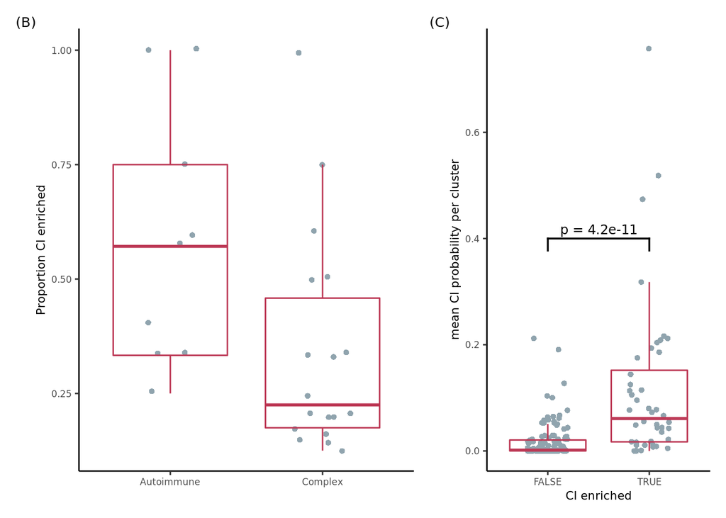

```r
Fig2a_fixed = Fig2a + theme(text = element_text(size = 8))
Fig2b = Fig2b + theme(text = element_text(size = 8))
Fig2c = Fig2c + theme(text = element_text(size = 8))

Fig2_bottom = (Fig2b | Fig2c) +  plot_layout(widths = c(3, 2))

ggsave(Fig2_bottom, file = paste0(figure_path, "/Figure2_bottom.png"),
       width = 85, height = 51, dpi = 300, units = "mm")

ggsave(Fig2a_fixed, file = paste0(figure_path, "/Figure2_top.png"),
       width = 85, height = 25.5, dpi = 300, units = "mm")

Fig2_bottom
```